# CM3070 Computer Science Final Project

## Bird Species Multiclass Classification (Deep Learning)

### Template: CM3015 Machine Learning and Neural Networks

### Project Idea Title 1: Deep Learning on a public dataset

### Kaori Murakami

**Libraries used**

```python
import numpy as np
import pandas as pd
import os
import sys
import random
import tensorflow as tf
from tensorflow import random as tf_random
import random as python_random
import matplotlib
import matplotlib.pyplot as plt
from tensorflow.keras.preprocessing.image import ImageDataGenerator, load_img, img_to_array, array_to_img
from tensorflow.keras import layers, models, utils
from tensorflow.keras.metrics import Precision, Recall
import sklearn
from sklearn.metrics import classification_report, accuracy_score, precision_score, recall_score, f1_score
from keras.models import load_model
from numpy import expand_dims
import keras_tuner as kt
```

**Version**

```python
print('Python version')
!python -V
```

```
Python version
Python 3.7.9
```

```python
print('Python version:', sys.version)

print('tensorflow:', tf.__version__)
print('keras:', tf.keras.__version__)
print('sklearn:', sklearn.__version__)
print('matplotlib:', matplotlib.__version__)
print('pandas:', pd.__version__)
print('numpy:', np.__version__)
```

```
Python version: 3.7.9 (default, Aug 31 2020, 17:10:11) [MSC v.1916 64 bit (AMD64)]
tensorflow: 2.9.1
keras: 2.9.0
sklearn: 0.23.2
matplotlib: 3.3.2
pandas: 1.2.0
numpy: 1.21.6
```

```python
BASE_DIR = '.\\100-bird-species'
TRAIN_DIR = os.path.join(BASE_DIR, 'train')
VAL_DIR = os.path.join(BASE_DIR, 'valid')
TEST_DIR = os.path.join(BASE_DIR, 'test')
RANDOM_SEED = 123
IMG_SIZE = 224
REDUCED_IMG_SIZE = 150
BATCH_SIZE = 32
```

```python
# set random seed for reproducibility
np.random.seed(RANDOM_SEED)
python_random.seed(RANDOM_SEED)
tf_random.set_seed(RANDOM_SEED)
```

The methodology of this project will follow Chollet (2018)'s process "Universal workflow of machine learning", which can be found in chapter 4.5 of Deep Learning with Python [1].

## 1. Defining the problem and assembling a dataset

**Dataset**  
The selected dataset "BIRDS 400 - SPECIES IMAGE CLASSIFICATION" is a public dataset available at Kaggle which features pictures of 400 bird species with a total of 58388 Train, 2000 Test and 2000 Validation images. It can be found at: https://www.kaggle.com/datasets/gpiosenka/100-bird-species [2].

**Type of input data**  
The dataset is a collection of colored 224X224X3 bird images, which will have to be converted into tensors of shape (height, width, channels).

**Type of problem**  
The problem involves classifying the images of bird species. Therefore, it is a multiclass image classification problem.

**Hypothesis**  
Convolutional neural networks can predict bird species with a high accuracy based on images. The goal of this deep learning project is to reach an accuracy higher than 85% (average of the models from the literature review).

## 2. Choosing a measure of success

Based on the dataset's description, the training set is not fully balanced. Although each species has at least 120 pictures in the training set, there are some species with more training data [2].

According to Chollet (2018) [1], class-imbalanced problems can benefit from metrics such as precision and recall.

Since we are facing a slightly imbalanced dataset, I will use the evaluation metrics of accuracy (ratio of correct predictions), as well as aditional metrics: precision (ratio of true positives from all positive predictions) and recall (ratio of true positives from all positive values). In this case, I will seek a balance between recall and precision, and take into consideration a high F1 score.

## 3. Deciding on an evaluation protocol

The selected dataset is already distributed into training, validation and testing datasets, with 58388, 2000, 2000 images respectively. Since there are a lot of training images available, I will use the hold-out method.

Selected evaluation protocol: hold-out validation set.

## 4. Prepare data

### Standardize the data

The images from the dataset are colored and thus, the RGB channel values are between the range of [0, 255]. For neural networks, the data should be formatted as tensors and scaled to small values. Therefore, the images' RGB values are standardized to be in the range of [0, 1].

I will be using ImageDataGenerator to load the images from the different directories and rescale the images' values.

```python
img_generator = ImageDataGenerator(rescale=1./255)
```

At the start I will reduce the image size from 224x224 px to 150x150 px to reduce training time. For the final or improved models I will use the original size of 224x224 px.

```python
# args for all sets (training, validation and test) with reduced image size
dataflow_args_reduced_img = {
    'target_size': (REDUCED_IMG_SIZE, REDUCED_IMG_SIZE),
    'class_mode': 'categorical',
    'color_mode': 'rgb',
    'batch_size': BATCH_SIZE,
    'seed': RANDOM_SEED,
}
```

```python
# data generators with 150x150 images
train_generator_reduced_img = img_generator.flow_from_directory(directory=TRAIN_DIR, shuffle=True, **dataflow_args_reduced_img)

val_generator_reduced_img = img_generator.flow_from_directory(directory=VAL_DIR, shuffle=False, **dataflow_args_reduced_img)

test_generator_reduced_img = img_generator.flow_from_directory(directory=TEST_DIR, shuffle=False, **dataflow_args_reduced_img)
```

```
Found 58388 images belonging to 400 classes.
Found 2000 images belonging to 400 classes.
Found 2000 images belonging to 400 classes.
```

```python
# args for all sets (training, validation and test) with original image size
dataflow_args = {
    'target_size': (IMG_SIZE, IMG_SIZE),
    'class_mode': 'categorical',
    'color_mode': 'rgb',
    'batch_size': BATCH_SIZE,
    'seed': RANDOM_SEED,
}
```

```python
# data generators with original 224x224 images
train_generator = img_generator.flow_from_directory(directory=TRAIN_DIR, shuffle=True, **dataflow_args)

val_generator = img_generator.flow_from_directory(directory=VAL_DIR, shuffle=False, **dataflow_args)

test_generator = img_generator.flow_from_directory(directory=TEST_DIR, shuffle=False, **dataflow_args)
```

```
Found 58388 images belonging to 400 classes.
Found 2000 images belonging to 400 classes.
Found 2000 images belonging to 400 classes.
```

```python
# save classes names into a dictionary
classes_dict = {}
for key,value in test_generator.class_indices.items():
    classes_dict[value]=key
```

## 5. Developing a model that does better than a baseline

The objective of this step is to create an initial model with statistical power that is able to beat a random baseline. This is a multiclass classification with 400 classes and thus, the model has to achieve an accuracy better than 0.25% to beat a random baseline.

## Prototype

This prototype model's performance will be then used as a baseline for the future models. Subsequent models will improve and aim for a higher accuracy and f1-score. The prototype is a simple convolutional network with three convolution layers and max pooling.

Since we are dealing with a multiclass single-label classification problem, the models will use a categorical_crossentropy loss function and with softmax as the last layer activation [1].

The categorical_crossentropy loss function computes the loss between true labels and predictions and is used when there are two or more classes [4]. In classification problems, the activation function used in the last layer is softmax as it results on a probability distribution [5].

The following functions will be used for plotting graphs.

```python
#*********************************
# Source code
# Author: CHOLLET, F
# Source: Deep Learning with Python [1]
#*********************************
def weighted_smooth_curve(data, factor=0.8):
    """Smooth the values by calculating the exponential moving average
       Replace each data point with a weighted sum of itself and the previous smooth point

    Parameters
    ----------
    data : list
        Data points
    factor : float
        Weighting factor

    Returns
    -------
    smoothed_data : list
        Smoothed data points by putting more weight on recent data
    """
    smoothed_data = []
    for point in data:
        if smoothed_data:
            prev_point = smoothed_data[-1]
            smoothed_data.append(prev_point * factor + point * (1 - factor))
        else:
            smoothed_data.append(point)
    return smoothed_data
```

```python
#*********************************
# Adapted from module's lectures
# Author: WARD, J. AND BLACKWELL, T. University of London
# Source: CM3015 Machine Learning and Neural Networks. University of London [3]
#*********************************
def plot_loss_acc_validation_curve(train_loss, val_loss, train_acc, val_acc):

    """Display two plots: loss validation curve and accuracy validation curve

    Parameters
    ----------
    train_loss : list
        Loss data points for Training
    val_loss : list
        Loss data points for Validation
    train_acc : list
        Accuracy data points for Training
    val_loss2 : list
        Accuracy data points for Validation

    Returns
    -------
    Displays two matplotlib plots
    """

    epoch_range = range(1, len(train_loss) + 1)

    fig, axs = plt.subplots(1, 2, figsize=(15,5))
    axs[0].plot(epoch_range, train_loss, label='Training loss')
    axs[0].plot(epoch_range, val_loss, label='Validation loss')
    axs[0].set_title('Training and Validation Loss')
    axs[0].set_xlabel('Epochs')
    axs[0].set_ylabel('Loss')
    axs[0].legend()

    axs[1].plot(epoch_range, train_acc, label='Training accuracy')
    axs[1].plot(epoch_range, val_acc, label='Validation accuracy')
    axs[1].legend()
    axs[1].set_title('Training and Validation Accuracy')
    axs[1].set_xlabel('Epochs')
    axs[1].set_ylabel('Accuracy')

    fig.tight_layout()
```

```python
#*********************************
# Adapted from module's lectures
# Author: WARD, J. AND BLACKWELL, T. University of London
# Source: CM3015 Machine Learning and Neural Networks. University of London [3]
#*********************************
def plot_loss_acc_val_curves_from_history(history):

    """Plots Train and Validation, Loss and Accuracy curves

    Parameters
    ----------
    history : dictionary
        dictionary with loss, val_loss, acc and val_acc values

    Returns
    -------
    Plots Train and Validation, Loss and Accuracy curves
    """

    train_loss = weighted_smooth_curve(history['loss'])
    val_loss = weighted_smooth_curve(history['val_loss'])
    train_acc = weighted_smooth_curve(history['acc'])
    val_acc = weighted_smooth_curve(history['val_acc'])

    plot_loss_acc_validation_curve(train_loss, val_loss, train_acc, val_acc)
```

```python
def print_metrics(score, model_name):

    """Prints the accuracy, precision, recall and F1-score

    Parameters
    ----------
    score : list of numbers
        List of metrics where 0: loss, 1: accuracy, 2: precision, 3: recall
    model_name : string
        Name of the model

    Returns
    -------
    Prints the accuracy, precision, recall and F1-score
    """

    acc = score[1]
    prec = score[2]
    rec = score[3]
    f1 = (2 * prec * rec)/(prec + rec)

    print(model_name, 'Score')
    print('Accuracy:', acc)
    print('Precision:', prec)
    print('Recall:', rec)
    print('F1-score:', f1)
```

```python
def get_classification_report(test_classes, test_names, y_pred):

    """Returns classes with high F1-score and classes with low F1-score

    Parameters
    ----------
    test_classes : list
        list of the test classes (int)
    test_names : numpy.ndarray
        list of the labels of test classes
    y_pred : list
        list of predictions

    Returns
    -------
    top_performance_classes : pandas.DataFrame
        classes with F1-score greater or equal to 80%
    low_performance_classes : pandas.DataFrame
        classes with F1-score less than 50%
    """

    classification_dict = classification_report(test_classes,
                                                y_pred,
                                                target_names=test_names,
                                                output_dict=True)

    results = pd.DataFrame(classification_dict).transpose()
    results = results[:-3]

    all_classes = results.sort_values(by='f1-score', ascending=False)
    top_performance_classes = results[results['f1-score'] >= 0.8].sort_values(by='f1-score', ascending=False)
    low_performance_classes = results[results['f1-score'] < 0.5].sort_values(by='f1-score', ascending=False)

    return all_classes, top_performance_classes, low_performance_classes
```

### Prototype Model

Since the prototype model has been trained already. The model will be loaded from a .h5 file.

```python
# number of classes
CLASSES_COUNT = len(os.listdir(TRAIN_DIR))
print('Number of classes:', CLASSES_COUNT)
```

```
Number of classes: 400
```

The prototype model consists of three convolutional layers, each one with 32 filters and a kernel size of (3, 3). Each convolutional model is followed by ReLu activation and max pooling.

```python
#*********************************
# Adapted from
# Author: CHOLLET, F.
# Source: Deep Learning with Python
#*********************************
def get_prototype_model():

    model_prototype=models.Sequential()

    model_prototype.add(layers.Conv2D(32, (3, 3), activation='relu', input_shape=(IMG_WIDTH, IMG_HEIGHT, 3)))
    model_prototype.add(layers.MaxPooling2D((2, 2)))
    model_prototype.add(layers.Conv2D(32, (3, 3), activation='relu'))
    model_prototype.add(layers.MaxPooling2D((2, 2)))
    model_prototype.add(layers.Conv2D(32, (3, 3), activation='relu'))
    model_prototype.add(layers.MaxPooling2D((2, 2)))

    model_prototype.add(layers.Flatten())
    model_prototype.add(layers.Dense(64, activation='relu'))
    model_prototype.add(layers.Dense(CLASSES_COUNT, activation='softmax'))

    model_prototype.compile(optimizer='rmsprop',
                    loss='categorical_crossentropy',
                    metrics=['acc', Precision(name='precision'), Recall(name='recall')])

    return model_prototype
```

```python
# load prototype model that has been previously trained
prototype_model = models.load_model('./models_all/prototype/model.h5')
```

```python
prototype_model.summary()
```

```
Model: "sequential"
_________________________________________________________________
 Layer (type)                Output Shape              Param #
=================================================================
 conv2d (Conv2D)             (None, 148, 148, 32)      896

 max_pooling2d (MaxPooling2D  (None, 74, 74, 32)       0
 )

 conv2d_1 (Conv2D)           (None, 72, 72, 32)        9248

 max_pooling2d_1 (MaxPooling  (None, 36, 36, 32)       0
 2D)

 conv2d_2 (Conv2D)           (None, 34, 34, 32)        9248

 max_pooling2d_2 (MaxPooling  (None, 17, 17, 32)       0
 2D)

 flatten (Flatten)           (None, 9248)              0

 dense (Dense)               (None, 64)                591936

 dense_1 (Dense)             (None, 400)               26000

=================================================================
Total params: 637,328
Trainable params: 637,328
Non-trainable params: 0
_________________________________________________________________
```

**Train Model**

Since the model was trained and saved. The history of the training was also saved as a csv file.

The prototype model was trained for epochs using the train images and validation images.

```python
def train_prototype_model(prototype_model):

    history = prototype_model.fit(train_generator_reduced_img,
                                steps_per_epoch=train_generator_reduced_img.samples // train_generator_reduced_img.batch_size,
                                epochs=20,
                                validation_data=val_generator_reduced_img,
                                validation_steps=val_generator_reduced_img.samples // val_generator_reduced_img.batch_size,
                                verbose=1)

    return history
```

```python
prototype_history = pd.read_csv('./models_all/prototype/model_history.csv')
```

### Validation Curves

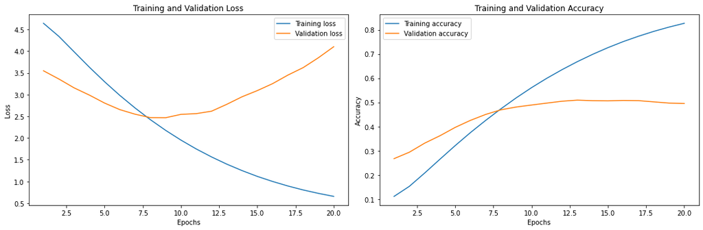

```python
plot_loss_acc_val_curves_from_history(prototype_history)
```

The loss curve shows that the prototype model is overfitting as the validation loss increases while the training loss decreases.

### Prototype Performance

The prototype achieved an accuracy of 52% and 53% F1 score.

**Overall Performance**

```python
# get overall score on prediction
score = prototype_model.evaluate(test_generator_reduced_img)
```

```python
print_metrics(score, 'Prototype')
```

```
Prototype Score
Accuracy: 0.5230000019073486
Precision: 0.5550135374069214
Recall: 0.5120000243186951
F1-score: 0.5326397992355087
```

**Performance by class**

Only 58 bird species achieved a F1 score of at least 80% while the 159 species got a F1 score of 50% or less. The prototype model is able to classify better a handful of species but performs poorly on others.

```python
Y_pred = prototype_model.predict(test_generator_reduced_img)
y_pred = np.argmax(Y_pred, axis=1)
```

```python
all_classes_prototype, top_classes_prototype, low_classes_prototype = get_classification_report(test_generator_reduced_img.classes,
                                                     test_generator_reduced_img.class_indices.keys(),
                                                     y_pred)
```

```python
print('Number of bird classes with a F1-Score of at least 80%:', len(top_classes_prototype), '(', (len(top_classes_prototype)/CLASSES_COUNT)*100,'%)')
```

```
Number of bird classes with a F1-Score of at least 80%: 58 ( 14.499999999999998 %)
```

```python
top_classes_prototype[:10]
```

|  | precision | recall | f1-score | support |
| --- | --- | --- | --- | --- |
| BLACK & YELLOW BROADBILL | 1.000000 | 1.0 | 1.000000 | 5.0 |
| HORNED SUNGEM | 1.000000 | 1.0 | 1.000000 | 5.0 |
| HIMALAYAN MONAL | 1.000000 | 1.0 | 1.000000 | 5.0 |
| GREEN BROADBILL | 1.000000 | 1.0 | 1.000000 | 5.0 |
| ROSY FACED LOVEBIRD | 0.833333 | 1.0 | 0.909091 | 5.0 |
| BEARDED BELLBIRD | 0.833333 | 1.0 | 0.909091 | 5.0 |
| RED BROWED FINCH | 0.833333 | 1.0 | 0.909091 | 5.0 |
| RAZORBILL | 0.833333 | 1.0 | 0.909091 | 5.0 |
| BULWERS PHEASANT | 0.833333 | 1.0 | 0.909091 | 5.0 |
| INDIAN PITTA | 0.833333 | 1.0 | 0.909091 | 5.0 |

```python
print('Number of bird classes with a F1-Score less than 50%:', len(low_classes_prototype), '(', (len(low_classes_prototype)/CLASSES_COUNT)*100,'%)')
```

```
Number of bird classes with a F1-Score less than 50%: 159 ( 39.75 %)
```

```python
print('Number of bird classes with F1 score of 0: ', len(all_classes_prototype[all_classes_prototype['precision'] == 0]))
```

```
Number of bird classes with F1 score of 0:  25
```

```python
low_classes_prototype.tail(10)
```

|  | precision | recall | f1-score | support |
| --- | --- | --- | --- | --- |
| SPOON BILED SANDPIPER | 0.0 | 0.0 | 0.0 | 5.0 |
| BORNEAN LEAFBIRD | 0.0 | 0.0 | 0.0 | 5.0 |
| ABBOTTS BOOBY | 0.0 | 0.0 | 0.0 | 5.0 |
| OSPREY | 0.0 | 0.0 | 0.0 | 5.0 |
| PELICAN | 0.0 | 0.0 | 0.0 | 5.0 |
| COMMON HOUSE MARTIN | 0.0 | 0.0 | 0.0 | 5.0 |
| KAGU | 0.0 | 0.0 | 0.0 | 5.0 |
| ROUGH LEG BUZZARD | 0.0 | 0.0 | 0.0 | 5.0 |
| EMU | 0.0 | 0.0 | 0.0 | 5.0 |
| KING VULTURE | 0.0 | 0.0 | 0.0 | 5.0 |

This simpler convolutional neural network will be used as a baseline to compare future tuned models.

## Option 1: Model from scratch (no pre-trained)

This method involves building a model from scratch without using any pre-trained model.

## 6. Develop a model that overfits

In this step, we try to build a model that is overfitting, that is, when the performance starts detereorating in the validation set while improving on the training set. Overfitting results when a model learns the training data into detail and cannot generalize it into new data and thus, the performance on unseen data is worse [1].

```python
#*********************************
# Adapted from module's lectures
# Author: WARD, J. AND BLACKWELL, T. University of London
# Source: CM3015 Machine Learning and Neural Networks. University of London [3]
#*********************************
def plot_metric_models(model_histories, num_epochs, metric, metric_label):

    """Display plots of the selected metric for each model in model_histories

    Parameters
    ----------
    model_histories: dict
        Dictionary metric histories

    num_epochs: int
        Number of epochs (data points)

    metric: str
        Metric to plot. E.g: val_loss

    metric_label: str
        Labels of the metric to be displayed on the graph

    Returns
    -------
    Display matplotlib plots of the selected metric for each model in model_histories
    """

    epochs = range(1, num_epochs + 1)
    colors = ['tab:blue', 'tab:orange', 'tab:green', 'tab:red', 'tab:pink']

    fig, axs = plt.subplots(1, 2, figsize=(15,5))

    for i, model in enumerate(model_histories):
        metric_data = weighted_smooth_curve(model_histories[model][metric])
        axs[0].plot(epochs, metric_data, colors[i], label = model)
        axs[0].set_title('Training ' + metric_label)
        axs[0].set_xlabel('Epochs')
        axs[0].set_ylabel(metric_label)
        axs[0].legend()

    for i, model in enumerate(model_histories):
        metric_data = weighted_smooth_curve(model_histories[model]['val_' + metric])
        axs[1].plot(epochs, metric_data, colors[i], label = model)
        axs[1].set_title('Validation ' + metric_label)
        axs[1].set_xlabel('Epochs')
        axs[1].set_ylabel(metric_label)
        axs[1].legend()
```

### Add more layers and make the layers bigger

I have built models with different number of layers and sizes (number of filters). Each of these models were trained for 20 epochs. The summary of the models architecture are as follows:

| Model | Conv Layers | Dense Layers | Trainable Params |
| --- | --- | --- | --- |
| 4 layers | 4 | 2 | 1,838,864 |
| 5 layers | 5 | 2 | 1,155,344 |
| 6 layers | 6 | 2 | 4,113,680 |
| 6 layers | 6 | 2 | 15,498,448 |

Although there are two models with 6 convolutional layers, the last one has larger and increasing number of filters on each layer.

```python
# load model histories
history_model_4layers = pd.read_csv('./models_all/scratch/overfit/model_4layers/model_history.csv')
history_model_5layers = pd.read_csv('./models_all/scratch/overfit/model_5layers/model_history.csv')
history_model_6layers = pd.read_csv('./models_all/scratch/overfit/model_6layers/model_history.csv')
history_model_6layers_bigger = pd.read_csv('./models_all/scratch/overfit/model_6layers_bigger/model_history.csv')

# add to dictionary of histories
model_histories = {}
model_histories['4conv_layers'] = history_model_4layers
model_histories['5conv_layers'] = history_model_5layers
model_histories['6conv_layers'] = history_model_6layers
model_histories['6conv_layers_bigger'] = history_model_6layers_bigger
```

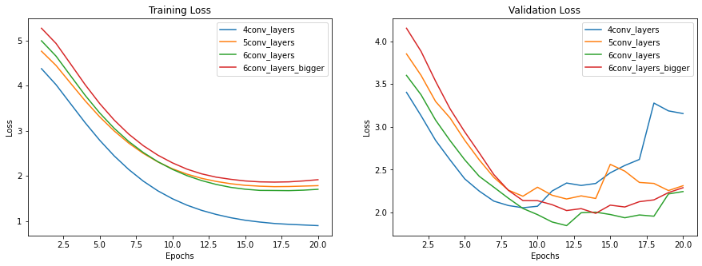

```python
plot_metric_models(model_histories, 20, 'loss', 'Loss')
```

The model with 4 convolutional layers is the one that overfits the most as the validation loss rapidly increases after the 10 epochs while the training loss decreases.

```python
# load model with 4 conv2D layers
model_4layers = models.load_model('./models_all/scratch/overfit/model_4layers/model.h5')
model_4layers.summary()
```

```
Model: "sequential"
_________________________________________________________________
 Layer (type)                Output Shape              Param #
=================================================================
 conv2d (Conv2D)             (None, 148, 148, 32)      896

 max_pooling2d (MaxPooling2D  (None, 74, 74, 32)       0
 )

 conv2d_1 (Conv2D)           (None, 72, 72, 64)        18496

 max_pooling2d_1 (MaxPooling  (None, 36, 36, 64)       0
 2D)

 conv2d_2 (Conv2D)           (None, 34, 34, 64)        36928

 max_pooling2d_2 (MaxPooling  (None, 17, 17, 64)       0
 2D)

 conv2d_3 (Conv2D)           (None, 15, 15, 128)       73856

 max_pooling2d_3 (MaxPooling  (None, 7, 7, 128)        0
 2D)

 flatten (Flatten)           (None, 6272)              0

 dense (Dense)               (None, 256)               1605888

 dense_1 (Dense)             (None, 400)               102800

=================================================================
Total params: 1,838,864
Trainable params: 1,838,864
Non-trainable params: 0
_________________________________________________________________
```

### Train for more epochs

For the previous models, I have used 20 epochs. Now I will increase the number to epochs to 50.

```python
history_model_4layers_more_epochs = pd.read_csv('./models_all/scratch/overfit/model_4layers_50epochs/model_history.csv')
```

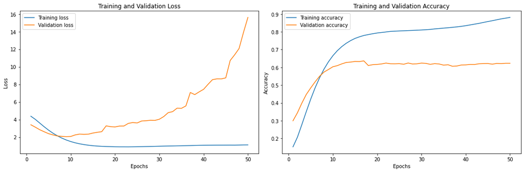

```python
plot_loss_acc_val_curves_from_history(history_model_4layers_more_epochs)
```

```python
print('Epoch that reaches minimum val loss: ', np.argmin(history_model_4layers_more_epochs['val_loss']), 'epochs')
```

```
Epoch that reaches minimum val loss:  4 epochs
```

```python
print('Epoch that reaches maximum val loss: ', np.argmax(history_model_4layers_more_epochs['val_loss']), 'epochs')
```

```
Epoch that reaches maximum val loss:  49 epochs
```

```python
model_4layers_more_epochs = models.load_model('./models_all/scratch/overfit/model_4layers_50epochs/model.h5')
```

```python
model_4layers_more_epochs.evaluate(test_generator_reduced_img)
```

```
[18.94197654724121, 0.6660000085830688, 0.6663331389427185, 0.6660000085830688]
```

From around the epoch 4, the performance on the validation data starts declining. At 49 epochs, the model reaches tha maximum loss value.

Now that an overfitting model has been found, the model can be modified and tuned to achieved a better performance.

## 7. Regularize the model and hyperparameter tuning

This step involves repeatedly modifying the model using different techniques to reduce overfitting and improve the model's performance on unseen data.

### Add weight regularization

Weight regularization is used to diminish overfitting by adding a cost with having large weights and thus, forcing the weights of the network to small values. There are two types: L1 regularization that adds the absolute value of the weight coefficients as a penalty to the loss function. L2 regularization adds the square of the value of the weight coefficients as a penalty [1].

L2 regularization was added to each convolutional layer for the weight penalty.

```python
def get_model_weight_regularization():

    model_scratch=models.Sequential()

    model_scratch.add(layers.Conv2D(32, (3, 3), activation='relu',
                                    kernel_initializer='he_normal',
                                    input_shape=(IMG_WIDTH, IMG_HEIGHT, 3)))
    model_scratch.add(layers.MaxPooling2D((2, 2)))
    model_scratch.add(layers.Conv2D(64, (3, 3),
                                    activation='relu',
                                    kernel_regularizer=regularizers.l2(l=0.01)))
    model_scratch.add(layers.MaxPooling2D((2, 2)))
    model_scratch.add(layers.Conv2D(64, (3, 3),
                                    activation='relu',
                                    kernel_regularizer=regularizers.l2(l=0.01)))
    model_scratch.add(layers.MaxPooling2D((2, 2)))
    model_scratch.add(layers.Conv2D(128, (3, 3),
                                    activation='relu',
                                    kernel_regularizer=regularizers.l2(l=0.01)))
    model_scratch.add(layers.MaxPooling2D((2, 2)))

    model_scratch.add(layers.Flatten())
    model_scratch.add(layers.Dense(256, activation='relu'))
    model_scratch.add(layers.Dense(CLASSES_COUNT, activation='softmax'))

    model_scratch.compile(optimizer='rmsprop',
                    loss='categorical_crossentropy',
                    metrics=['acc', Precision(name='precision'), Recall(name='recall')])

    return model_scratch
```

```python
history_model_4layers_regularization = pd.read_csv('./models_all/scratch/tune_model/model_4layers_regularization/model_history.csv')
```

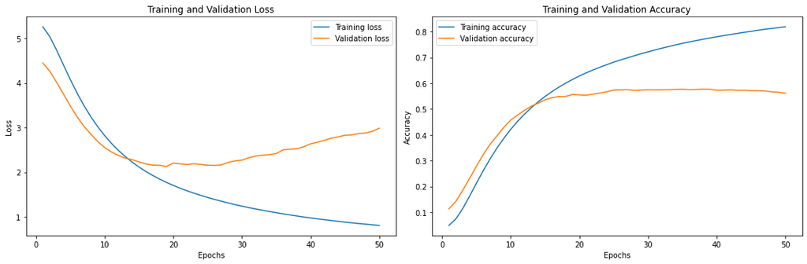

```python
plot_loss_acc_val_curves_from_history(history_model_4layers_regularization)
```

Although it starts overfitting after 15 epochs, it does so slower than without weight regularization.

```python
print('Epoch that reaches minimum val loss: ', np.argmin(history_model_4layers_regularization['val_loss']), 'epochs')
```

```
Epoch that reaches minimum val loss:  15 epochs
```

```python
print('Epoch that reaches maximum val loss: ', np.argmax(history_model_4layers_regularization['val_loss']), 'epochs')
```

```
Epoch that reaches maximum val loss:  0 epochs
```

```python
model_4layers_regularization = models.load_model('./models_all/scratch/tune_model/model_4layers_regularization/model.h5')
```

### Add dropout

Dropout is a regularization technique that involves randomly zero out a certain percentage of the output features from a given layer during the training. During testing, features are scaled down instead of being dropped out. The dropout rate is the proportion of features to be dropped out and it is generally set between 0.2 and 0.5 [1]. Dropout improves overfitting by adding noise to the output of a layer and removing patterns that are not significant.

A dropout of 0.2 was added before the first dense layer.

```python
def get_model_dropout():

    model_scratch=models.Sequential()

    model_scratch.add(layers.Conv2D(32, (3, 3), activation='relu',
                                    kernel_initializer='he_normal',
                                    input_shape=(IMG_WIDTH, IMG_HEIGHT, 3)))
    model_scratch.add(layers.MaxPooling2D((2, 2)))
    model_scratch.add(layers.Conv2D(64, (3, 3),
                                    activation='relu',
                                    kernel_regularizer=regularizers.l2(l=0.01)))
    model_scratch.add(layers.MaxPooling2D((2, 2)))
    model_scratch.add(layers.Conv2D(64, (3, 3),
                                    activation='relu',
                                    kernel_regularizer=regularizers.l2(l=0.01)))
    model_scratch.add(layers.MaxPooling2D((2, 2)))
    model_scratch.add(layers.Conv2D(128, (3, 3),
                                    activation='relu',
                                    kernel_regularizer=regularizers.l2(l=0.01)))
    model_scratch.add(layers.MaxPooling2D((2, 2)))

    model_scratch.add(layers.Flatten())
    # add dropout
    model_scratch.add(layers.Dropout(0.2))
    model_scratch.add(layers.Dense(256, activation='relu'))
    model_scratch.add(layers.Dense(CLASSES_COUNT, activation='softmax'))

    model_scratch.compile(optimizer='rmsprop',
                    loss='categorical_crossentropy',
                    metrics=['acc', Precision(name='precision'), Recall(name='recall')])

    return model_scratch
```

```python
history_model_4layers_dropout = pd.read_csv('./models_all/scratch/tune_model/model_4layers_dropout/model_history.csv')
```

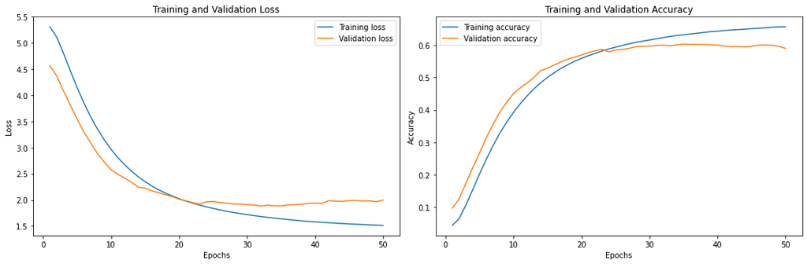

```python
plot_loss_acc_val_curves_from_history(history_model_4layers_dropout)
```

Adding dropout of 20% before the first dense layer significantly decreased overfitting.

```python
print('Epoch that reaches minimum val loss: ', np.argmin(history_model_4layers_dropout['val_loss']), 'epochs')
```

```
Epoch that reaches minimum val loss:  22 epochs
```

```python
print('Epoch that reaches maximum val loss: ', np.argmax(history_model_4layers_dropout['val_loss']), 'epochs')
```

```
Epoch that reaches maximum val loss:  0 epochs
```

```python
model_4layers_dropout = models.load_model('./models_all/scratch/tune_model/model_4layers_dropout/model.h5')
```

### Add Batch Normalization

Batch normalisation facilitates gradient backpropagation in deeper networks by keeping an exponential moving average of the batch mean and variance during training [1].

Batch Normalization was added after each Convolutional layer.

```python
def get_model_batch_normalization():

    model_scratch=models.Sequential()

    model_scratch.add(layers.Conv2D(32, (3, 3), activation='relu',
                                    kernel_initializer='he_normal',
                                    input_shape=(IMG_WIDTH, IMG_HEIGHT, 3)))
    model_scratch.add(layers.MaxPooling2D((2, 2)))
    model_scratch.add(layers.BatchNormalization())
    model_scratch.add(layers.Conv2D(64, (3, 3), activation='relu',
                                    kernel_regularizer=regularizers.l2(l=0.01)))
    model_scratch.add(layers.MaxPooling2D((2, 2)))
    model_scratch.add(layers.BatchNormalization())
    model_scratch.add(layers.Conv2D(64, (3, 3), activation='relu',
                                    kernel_regularizer=regularizers.l2(l=0.01)))
    model_scratch.add(layers.MaxPooling2D((2, 2)))
    model_scratch.add(layers.BatchNormalization())
    model_scratch.add(layers.Conv2D(128, (3, 3), activation='relu',
                                    kernel_regularizer=regularizers.l2(l=0.01)))
    model_scratch.add(layers.MaxPooling2D((2, 2)))
    model_scratch.add(layers.BatchNormalization())

    model_scratch.add(layers.Flatten())
    model_scratch.add(layers.Dropout(0.2))
    model_scratch.add(layers.Dense(256, activation='relu'))
    model_scratch.add(layers.Dense(CLASSES_COUNT, activation='softmax'))

    model_scratch.compile(optimizer='rmsprop',
                    loss='categorical_crossentropy',
                    metrics=['acc', Precision(name='precision'), Recall(name='recall')])

    return model_scratch
```

```python
history_model_4layers_batch = pd.read_csv('./models_all/scratch/tune_model/model_4layers_batch/model_history.csv')
```

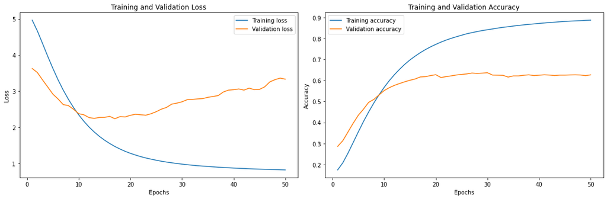

```python
plot_loss_acc_val_curves_from_history(history_model_4layers_batch)
```

```python
model_4layers_batch = models.load_model('./models_all/scratch/tune_model/model_4layers_batch/model.h5')
```

```python
model_4layers_batch.evaluate(test_generator_reduced_img)
```

```
[2.685551643371582, 0.6840000152587891, 0.7206434607505798, 0.671999990940094]
```

### Add or remove layers

The current model has 4 convolutional layers. Here we try to change the number of layers and find a suitable number that reduces overfitting.

**3 convolutional layers**

```python
history_model_3layers_batch = pd.read_csv('./models_all/scratch/tune_model/model_3layers/model_history.csv')
```

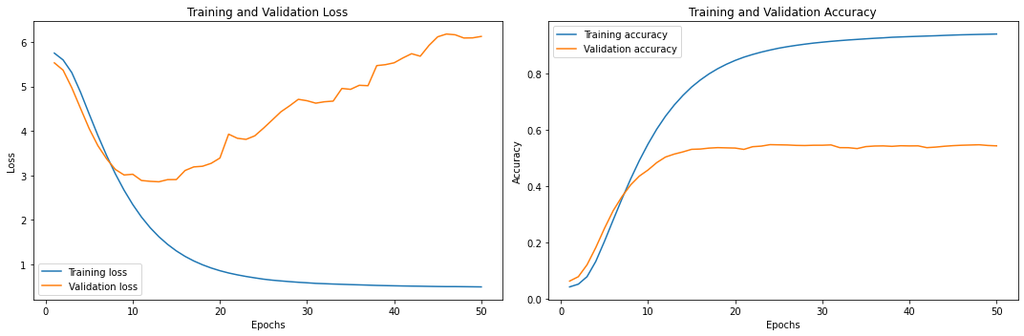

```python
plot_loss_acc_val_curves_from_history(history_model_3layers_batch)
```

```python
model_3layers_batch = models.load_model('./models_all/scratch/tune_model/model_3layers/model.h5')
```

Reducing the number of convolutional layers to 3 rapidly increases overfitting.

**5 convolutional layers**

```python
history_model_5layers_batch = pd.read_csv('./models_all/scratch/tune_model/model_5layers/model_history.csv')
```

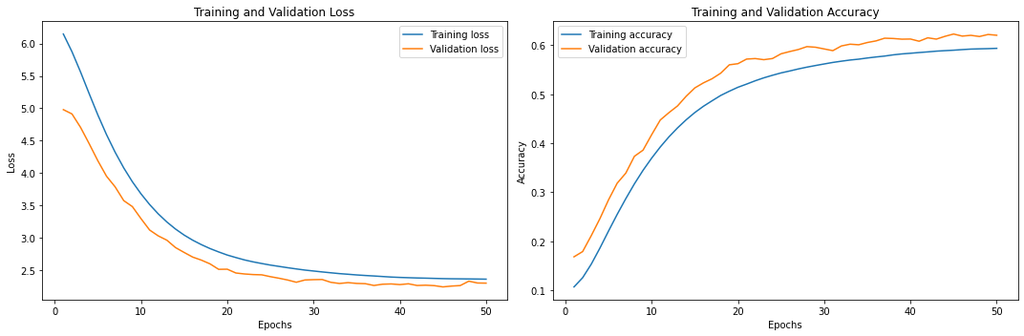

```python
plot_loss_acc_val_curves_from_history(history_model_5layers_batch)
```

```python
model_5layers_batch = models.load_model('./models_all/scratch/tune_model/model_5layers/model.h5')
```

**6 convolutional layers**

```python
history_model_6layers_batch = pd.read_csv('./models_all/scratch/tune_model/model_6layers/model_history.csv')
```

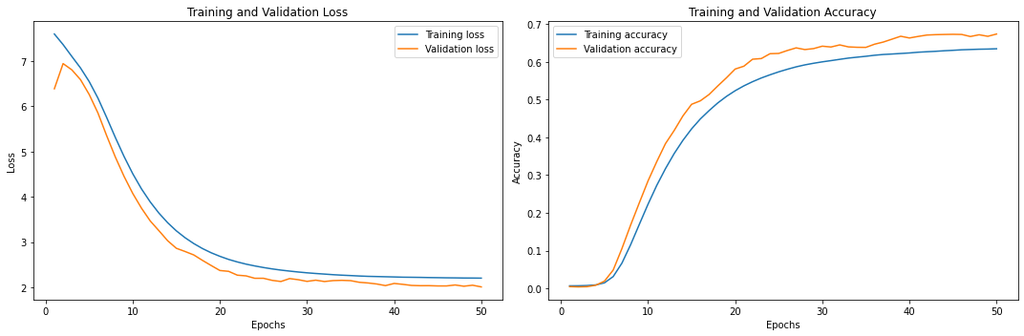

```python
plot_loss_acc_val_curves_from_history(history_model_6layers_batch)
```

```python
model_6layers_batch = models.load_model('./models_all/scratch/tune_model/model_6layers/model.h5')
```

```python
model_6layers_batch.evaluate(test_generator_reduced_img)
```

```
[1.7635880708694458, 0.7214999794960022, 0.869655191898346, 0.6305000185966492]
```

Increasing the number of layers to 6 convolutional layers significantly reduced overfitting and improved accuracy to 72%.

### Hyperparameter tuning

Hyperparameter tuning is the process of trying different hyperparameters in order to find the most optimal configuration. A common approach is to choose random hyperparameters to evaluate [1].

**Compare optimizers**

The current model uses the RMSProp optimizer. RMSProp divides the gradient by the root of the moving discounted average of the square of gradients [6]. Other commonly used optimizers include SGD and Adam. SGD consists of gradient descent with momentum [7] and Adam is a stochastic gradient descent with adaptive moment estimation [8].

**SGD**

```python
history_model_6layers_sgd = pd.read_csv('./models_all/scratch/tune_model/model_6layers_sgd/model_history.csv')
```

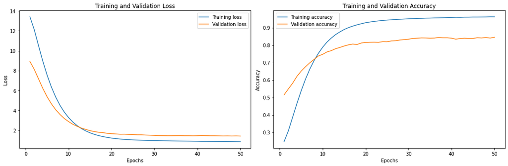

```python
plot_loss_acc_val_curves_from_history(history_model_6layers_sgd)
```

```python
model_6layers_sgd = models.load_model('./models_all/scratch/tune_model/model_6layers_sgd/model.h5')
```

```python
model_6layers_sgd.evaluate(test_generator_reduced_img)
```

```
[1.2343440055847168,
 0.8734999895095825,
 0.9050397872924805,
 0.8529999852180481]
```

**Adam**

```python
history_model_6layers_adam = pd.read_csv('./models_all/scratch/tune_model/model_6layers_adam/model_history.csv')
```

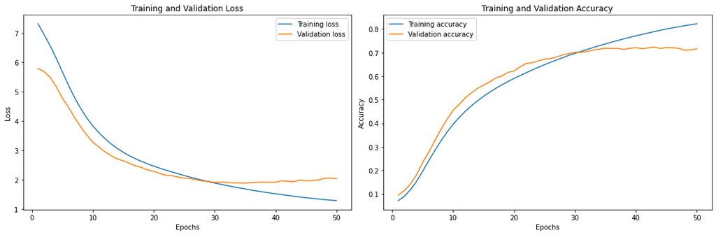

```python
plot_loss_acc_val_curves_from_history(history_model_6layers_adam)
```

```python
model_6layers_adam = models.load_model('./models_all/scratch/tune_model/model_6layers_adam/model.h5')
```

```python
model_6layers_adam.evaluate(test_generator_reduced_img)
```

```
[1.7980517148971558, 0.7540000081062317, 0.801328182220459, 0.7239999771118164]
```

Using SGD as the optimizer had a better performance.

**Hyperparameter Tuning with Keras Tuner**

Keras Tuner is a hyperparameter optimization framework that helps finding the best hyperparameter values for a given search space [9].

```python
tuned_test_data_generator = img_generator.flow_from_directory(directory=TEST_DIR,
                                                                shuffle=False,
                                                                target_size=(IMG_SIZE, IMG_SIZE),
                                                                class_mode='categorical',
                                                                color_mode='rgb',
                                                                batch_size=BATCH_SIZE,
                                                                seed=RANDOM_SEED)
```

```
Found 2000 images belonging to 400 classes.
```

The hyperparameter search space include the number of filters on the first convolutional layer, the sixth convolutional layer and the dense layer after the flattening. Furthermore, it includes the learning rate and momentum for the SGD optimizer.

**Hyperparameter tuned model**

```python
#*********************************
# Adapted from the following sources:
# Author: O'MALLEY, T., BURSZTEIN, E. LONG, J. CHOLLET, F
# Source: Keras Tuner. https://github.com/keras-team/keras-tuner [9]
#
# Author: ROSEBROCK, A
# Source: Easy Hyperparameter Tuning with Keras Tuner and TensorFlow. https://pyimagesearch.com/2021/06/07/easy-hyperparameter-tuning-with-keras-tuner-and-tensorflow/ [10]
#*********************************
def tune_model(hp):

    model_tune = models.Sequential()

    model_tune.add(layers.Conv2D(filters=hp.Int('conv_layer_1_filters', min_value=32, max_value=96, step=32, default=32),
                    kernel_size=(3, 3),
                    activation='relu',
                    kernel_initializer='he_normal',
                    input_shape=(IMG_WIDTH,IMG_HEIGHT,3)))
    model_tune.add(layers.MaxPooling2D((2, 2)))
    model_tune.add(layers.BatchNormalization())
    model_tune.add(layers.Conv2D(filters=64,
                    kernel_size=(3, 3),
                    activation='relu',
                    kernel_initializer='he_normal',
                    padding='same'))
    model_tune.add(layers.MaxPooling2D((2, 2)))
    model_tune.add(layers.BatchNormalization())
    model_tune.add(layers.Conv2D(filters=128,
                    kernel_size=(3, 3),
                    activation='relu',
                    kernel_initializer='he_normal',
                    padding='same'))
    model_tune.add(layers.MaxPooling2D((2, 2)))
    model_tune.add(layers.BatchNormalization())
    model_tune.add(layers.Conv2D(filters=256,
                    kernel_size=(3, 3),
                    activation='relu',
                    kernel_initializer='he_normal',
                    padding='same'))
    model_tune.add(layers.MaxPooling2D((2, 2)))
    model_tune.add(layers.BatchNormalization())
    model_tune.add(layers.Conv2D(filters=512,
                    kernel_size=(3, 3),
                    activation='relu',
                    kernel_initializer='he_normal',
                    padding='same'))
    model_tune.add(layers.MaxPooling2D((2, 2)))
    model_tune.add(layers.BatchNormalization())
    model_tune.add(layers.Conv2D(filters=hp.Int('conv_layer_6_filters', min_value=512, max_value=1536, step=512, default=1024),
                    kernel_size=(3, 3),
                    activation='relu',
                    kernel_initializer='he_normal',
                    padding='same'))

    model_tune.add(layers.Flatten())
    model_tune.add(layers.Dropout(0.2))
    model_tune.add(layers.Dense(units=hp.Int('dense_layer_1_units', min_value=1024, max_value=3072, step=1024, default=2048), activation='relu'))
    model_tune.add(layers.Dense(CLASSES_COUNT, activation='softmax'))

    model_tune.compile(optimizer=tf.keras.optimizers.SGD(hp.Choice('learning_rate', values=[1e-2, 1e-3, 1e-4], default=1e-2),
                               momentum=hp.Choice('momentum', [0.0, 0.2, 0.4, 0.6, 0.8], default=0.0)),
                  loss='categorical_crossentropy', metrics=['acc', Precision(name='precision'), Recall(name='recall')])

    return model_tune
```

```python
#*********************************
# Adapted from the following sources:
# Author: O'MALLEY, T., BURSZTEIN, E. LONG, J. CHOLLET, F
# Source: Keras Tuner. https://github.com/keras-team/keras-tuner [9]
#
# Author: ROSEBROCK, A
# Source: Easy Hyperparameter Tuning with Keras Tuner and TensorFlow. https://pyimagesearch.com/2021/06/07/easy-hyperparameter-tuning-with-keras-tuner-and-tensorflow/ [10]
#*********************************
def get_tuner_results():

    hyper_tuner = kt.Hyperband(
        tune_model,
        max_epochs=15,
        objective='val_acc',
        directory='tune_dir',
        factor=3,
        project_name='model_tune')

    hyper_tuner.search(train_data_generator,
                 steps_per_epoch=train_data_generator.samples // train_data_generator.batch_size,
                 validation_steps=validation_data_generator.samples // validation_data_generator.batch_size,
                 validation_data=validation_data_generator,
                 epochs=15)

    hyper_tuner_results = hyper_tuner.results_summary()

    return hyper_tuner_results
```

With keras tuner, the optimized hyperparameters include the use of SGD with 0.6 momentum and 0.01 learning rate.

Momentum is a method that addresses convergence speed and local minima, and helps accelerate gradient vectors [1].

The Keras Tuner best result was the following:

[figure not shown]

```python
history_model_tuned = pd.read_csv('./models_all/scratch/tune_model/model_keras_tune/model_history.csv')
```

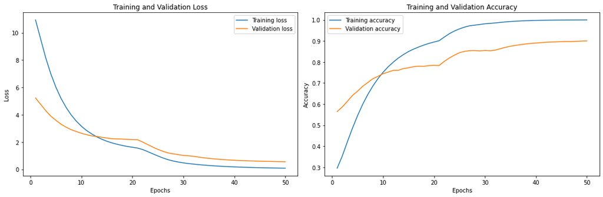

```python
plot_loss_acc_val_curves_from_history(history_model_tuned)
```

```python
model_tuned = models.load_model('./models_all/scratch/tune_model/model_keras_tune/model.h5')
```

```python
model_tuned.summary()
```

```
Model: "sequential"
_________________________________________________________________
 Layer (type)                Output Shape              Param #
=================================================================
 conv2d (Conv2D)             (None, 148, 148, 96)      2688

 max_pooling2d (MaxPooling2D  (None, 74, 74, 96)       0
 )

 batch_normalization (BatchN  (None, 74, 74, 96)       384
 ormalization)

 conv2d_1 (Conv2D)           (None, 74, 74, 65)        56225

 max_pooling2d_1 (MaxPooling  (None, 37, 37, 65)       0
 2D)

 batch_normalization_1 (Batc  (None, 37, 37, 65)       260
 hNormalization)

 conv2d_2 (Conv2D)           (None, 37, 37, 128)       75008

 max_pooling2d_2 (MaxPooling  (None, 18, 18, 128)      0
 2D)

 batch_normalization_2 (Batc  (None, 18, 18, 128)      512
 hNormalization)

 conv2d_3 (Conv2D)           (None, 18, 18, 256)       295168

 max_pooling2d_3 (MaxPooling  (None, 9, 9, 256)        0
 2D)

 batch_normalization_3 (Batc  (None, 9, 9, 256)        1024
 hNormalization)

 conv2d_4 (Conv2D)           (None, 9, 9, 512)         1180160

 max_pooling2d_4 (MaxPooling  (None, 4, 4, 512)        0
 2D)
```

[output cut: 10 more lines]

```
 hNormalization)

 flatten (Flatten)           (None, 6144)              0

 dropout (Dropout)           (None, 6144)              0

 dense (Dense)               (None, 2048)              12584960

 dense_1 (Dense)             (None, 400)               819600

=================================================================
Total params: 22,103,605
Trainable params: 22,098,419
Non-trainable params: 5,186
_________________________________________________________________
```

```python
scratch_best_no_aug_score = model_tuned.evaluate(test_generator_reduced_img)
```

```python
print_metrics(scratch_best_no_aug_score, 'Best tuned model from scratch with no data augmentation')
```

```
Best tuned model from scratch with no data augmentation Score
Accuracy: 0.9160000085830688
Precision: 0.9318298101425171
Recall: 0.9089999794960022
F1-score: 0.9202733279100641
```

Using the optimized hyperparameters from Keras Tune, the model achieved a higher accuracy of 91%.

### Data Augmentation

Data augmentation involves incrementing the number of training samples by applying a number of random transformations to the existing samples [1]. It is used to decrease overfitting.

```python
#*********************************
# Source code
# Author: Chollet
# Source: Deep Learning with Python. CHAPTER 5 Deep learning for computer vision [1]
#*********************************

def visualize_image_augmentation(img_path, datagen):

    """Displays 9 examples of the image augmentation applied to an image

    Parameters
    ----------
    img_path : str
        image path
    datagen : ImageDataGenerator
        image data generator with the data augmentation to be applied
    Returns
    -------
    Displays matplotlib plots of 9 image augmentation examples
    """

    # load the image
    bird_img = load_img(bird_aug_img_path, target_size=(224, 224))
    # convert to numpy array
    bird_img_data = img_to_array(bird_img)
    bird_img_data = bird_img_data.reshape((1,) + bird_img_data.shape)

    i=0
    plt.subplots(3,3,figsize=(8,8))
    for batch in datagen.flow(bird_img_data, batch_size=1):
        plt.subplot(3, 3, i+1)
        imgplot = plt.imshow(array_to_img(batch[0]))
        i += 1
        if i % 9 == 0:
            break

    plt.show()
```

The data augmentation applied includes:

```python
# image generator with data augmentation
aug_datagen = ImageDataGenerator(
                rescale=1./255,
                horizontal_flip=True,
                shear_range=0.2,
                rotation_range=40,
                zoom_range=0.2,
                height_shift_range=0.2,
                width_shift_range=0.2)
```

Example of image augmentation applied to be applied to the train dataset.

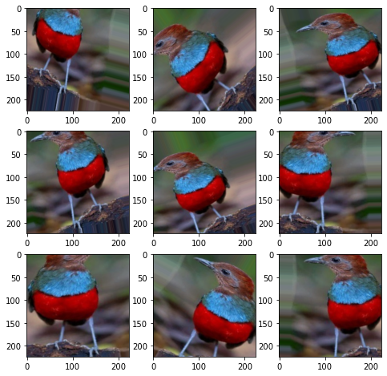

```python
bird_aug_img_path = os.path.join(TEST_DIR, 'RED BELLIED PITTA', '1.jpg')
visualize_image_augmentation(bird_aug_img_path, aug_datagen)
```

```python
history_model_tuned_data_aug = pd.read_csv('./models_all/scratch/tune_model/model_final_data_aug/model_history.csv')
```

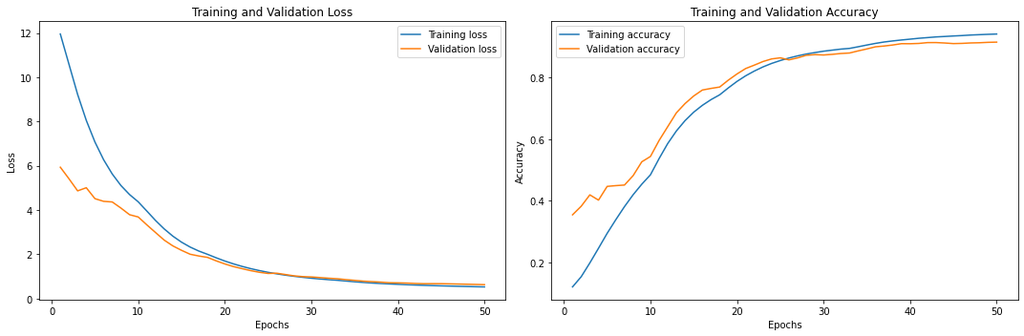

```python
plot_loss_acc_val_curves_from_history(history_model_tuned_data_aug)
```

```python
def get_best_scratch_model_data_aug():

    model_best_scratch=models.Sequential()

    model_best_scratch.add(layers.Conv2D(96, (3, 3), activation='relu',
                                         kernel_initializer='he_normal', input_shape=(IMG_WIDTH, IMG_HEIGHT, 3)))
    model_best_scratch.add(layers.MaxPooling2D((2, 2)))
    model_best_scratch.add(layers.BatchNormalization())

    model_best_scratch.add(layers.Conv2D(65, (3, 3), activation='relu',
                                         kernel_regularizer=regularizers.l2(l=0.01), padding='same'))
    model_best_scratch.add(layers.MaxPooling2D((2, 2)))
    model_best_scratch.add(layers.BatchNormalization())

    model_best_scratch.add(layers.Conv2D(128, (3, 3), activation='relu',
                                         kernel_regularizer=regularizers.l2(l=0.01), padding='same'))
    model_best_scratch.add(layers.MaxPooling2D((2, 2)))
    model_best_scratch.add(layers.BatchNormalization())

    model_best_scratch.add(layers.Conv2D(256, (3, 3), activation='relu',
                                         kernel_regularizer=regularizers.l2(l=0.01), padding='same'))
    model_best_scratch.add(layers.MaxPooling2D((2, 2)))
    model_best_scratch.add(layers.BatchNormalization())

    model_best_scratch.add(layers.Conv2D(512, (3, 3), activation='relu',
                                         kernel_regularizer=regularizers.l2(l=0.01), padding='same'))
    model_best_scratch.add(layers.MaxPooling2D((2, 2)))
    model_best_scratch.add(layers.BatchNormalization())

    model_best_scratch.add(layers.Conv2D(1536, (3, 3), activation='relu',
                                         kernel_regularizer=regularizers.l2(l=0.01), padding='same'))
    model_best_scratch.add(layers.MaxPooling2D((2, 2)))
    model_best_scratch.add(layers.BatchNormalization())

    model_best_scratch.add(layers.Flatten())
    # add dropout
    model_best_scratch.add(layers.Dropout(0.2))
    model_best_scratch.add(layers.Dense(2048, activation='relu'))
    model_best_scratch.add(layers.Dense(CLASSES_COUNT, activation='softmax'))

    model_best_scratch.compile(optimizer=tf.keras.optimizers.SGD(learning_rate=0.01, momentum= 0.6),
                    loss='categorical_crossentropy',
                    metrics=['acc', Precision(name='precision'), Recall(name='recall')])

    return model_best_scratch
```

```python
model_tuned_data_aug = models.load_model('./models_all/scratch/tune_model/model_final_data_aug/model.h5')
```

```python
model_tuned_data_aug.summary()
```

```
Model: "sequential"
_________________________________________________________________
 Layer (type)                Output Shape              Param #
=================================================================
 conv2d (Conv2D)             (None, 222, 222, 96)      2688

 max_pooling2d (MaxPooling2D  (None, 111, 111, 96)     0
 )

 batch_normalization (BatchN  (None, 111, 111, 96)     384
 ormalization)

 conv2d_1 (Conv2D)           (None, 111, 111, 65)      56225

 max_pooling2d_1 (MaxPooling  (None, 55, 55, 65)       0
 2D)

 batch_normalization_1 (Batc  (None, 55, 55, 65)       260
 hNormalization)

 conv2d_2 (Conv2D)           (None, 55, 55, 128)       75008

 max_pooling2d_2 (MaxPooling  (None, 27, 27, 128)      0
 2D)

 batch_normalization_2 (Batc  (None, 27, 27, 128)      512
 hNormalization)

 conv2d_3 (Conv2D)           (None, 27, 27, 256)       295168

 max_pooling2d_3 (MaxPooling  (None, 13, 13, 256)      0
 2D)

 batch_normalization_3 (Batc  (None, 13, 13, 256)      1024
 hNormalization)

 conv2d_4 (Conv2D)           (None, 13, 13, 512)       1180160

 max_pooling2d_4 (MaxPooling  (None, 6, 6, 512)        0
 2D)
```

[output cut: 10 more lines]

```
 hNormalization)

 flatten (Flatten)           (None, 13824)             0

 dropout (Dropout)           (None, 13824)             0

 dense (Dense)               (None, 2048)              28313600

 dense_1 (Dense)             (None, 400)               819600

=================================================================
Total params: 37,832,245
Trainable params: 37,827,059
Non-trainable params: 5,186
_________________________________________________________________
```

```python
scratch_best_aug_score = model_tuned_data_aug.evaluate(test_generator)
```

```python
print_metrics(scratch_best_aug_score, 'Best tuned model from scratch with data augmentation')
```

```
Best tuned model from scratch with data augmentation Score
Accuracy: 0.9434999823570251
Precision: 0.9583975076675415
Recall: 0.9330000281333923
F1-score: 0.9455282506098186
```

With data augmentation, the model from scratch improved its accuracy to 94.35% and F1 score to 94.55%.

**Top predicted classes**

```python
Y_pred_scratch_aug = model_tuned_data_aug.predict(test_generator)
y_pred_scratch_aug = np.argmax(Y_pred_scratch_aug, axis=1)
```

```python
all_classes_scratch_aug, top_classes_scratch_aug, low_classes_scratch_aug = get_classification_report(test_generator.classes,
                                                     test_generator.class_indices.keys(),
                                                     y_pred_scratch_aug)
```

```python
print('Number of bird classes with a F1-Score greater than 80%:', len(top_classes_scratch_aug), '(', (len(top_classes_scratch_aug)/CLASSES_COUNT)*100,'%)')
```

```
Number of bird classes with a F1-Score greater than 80%: 375 ( 93.75 %)
```

```python
print('Number of bird classes with a F1-Score less than 50%:', len(low_classes_scratch_aug))
```

```
Number of bird classes with a F1-Score less than 50%: 0
```

```python
all_classes_scratch_aug[-10:]
```

|  | precision | recall | f1-score | support |
| --- | --- | --- | --- | --- |
| BRANDT CORMARANT | 0.555556 | 1.0 | 0.714286 | 5.0 |
| NORTHERN FULMAR | 0.555556 | 1.0 | 0.714286 | 5.0 |
| LESSER ADJUTANT | 0.571429 | 0.8 | 0.666667 | 5.0 |
| CRESTED COUA | 0.571429 | 0.8 | 0.666667 | 5.0 |
| FAIRY TERN | 0.750000 | 0.6 | 0.666667 | 5.0 |
| IMPERIAL SHAQ | 0.750000 | 0.6 | 0.666667 | 5.0 |
| AVADAVAT | 0.500000 | 0.8 | 0.615385 | 5.0 |
| BALD IBIS | 0.600000 | 0.6 | 0.600000 | 5.0 |
| BAND TAILED GUAN | 1.000000 | 0.4 | 0.571429 | 5.0 |
| STRAWBERRY FINCH | 1.000000 | 0.4 | 0.571429 | 5.0 |

The tuned model with data augmentation achieved 375 bird species with F1 score of at least 80%. Compared to the prototype model, the improved and tuned model has no bird species with F1 score less than 50%.

### Separable convolutions

Depthwise separable convolution layers perform a spatial convolution on each channel and then combine the output channels through pointwise convolution. Since it requires less computations and parameters, the models are lighter and faster [1].

To compare the performance, the Conv2D layers are replaced by SeparableConv2D layers.

```python
history_model_separable_conv = pd.read_csv('./models_all/scratch/tune_model/model_separable_conv/model_history.csv')
```

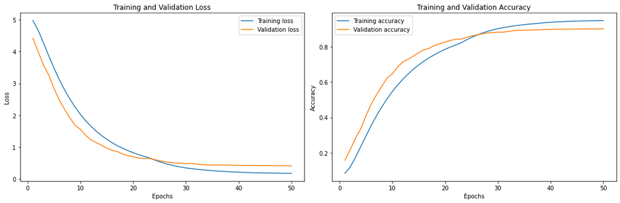

```python
plot_loss_acc_val_curves_from_history(history_model_separable_conv)
```

```python
model_separable_conv = models.load_model('./models_all/scratch/tune_model/model_separable_conv/model.h5')
```

```python
model_separable_conv.summary()
```

```
Model: "sequential"
_________________________________________________________________
 Layer (type)                Output Shape              Param #
=================================================================
 separable_conv2d (Separable  (None, 222, 222, 96)     411
 Conv2D)

 max_pooling2d (MaxPooling2D  (None, 111, 111, 96)     0
 )

 batch_normalization (BatchN  (None, 111, 111, 96)     384
 ormalization)

 separable_conv2d_1 (Separab  (None, 111, 111, 65)     7169
 leConv2D)

 max_pooling2d_1 (MaxPooling  (None, 55, 55, 65)       0
 2D)

 batch_normalization_1 (Batc  (None, 55, 55, 65)       260
 hNormalization)

 separable_conv2d_2 (Separab  (None, 55, 55, 128)      9033
 leConv2D)

 max_pooling2d_2 (MaxPooling  (None, 27, 27, 128)      0
 2D)

 batch_normalization_2 (Batc  (None, 27, 27, 128)      512
 hNormalization)

 separable_conv2d_3 (Separab  (None, 27, 27, 256)      34176
 leConv2D)

 max_pooling2d_3 (MaxPooling  (None, 13, 13, 256)      0
 2D)

 batch_normalization_3 (Batc  (None, 13, 13, 256)      1024
 hNormalization)

```

[output cut: 16 more lines]

```
 hNormalization)

 flatten (Flatten)           (None, 13824)             0

 dropout (Dropout)           (None, 13824)             0

 dense (Dense)               (None, 2048)              28313600

 dense_1 (Dense)             (None, 400)               819600

=================================================================
Total params: 30,120,825
Trainable params: 30,115,639
Non-trainable params: 5,186
_________________________________________________________________
```

```python
separable_conv_score = model_separable_conv.evaluate(test_generator)
```

```python
print_metrics(separable_conv_score, 'Separable convolutions with data augmentation')
```

```
Separable convolutions with data augmentation Score
Accuracy: 0.9244999885559082
Precision: 0.939703643321991
Recall: 0.9194999933242798
F1-score: 0.9294920435074067
```

Although the training time was faster with SeparableConv2D layers, the model with Conv2D achieved 94.35% accuracy while the SeparableConv2D model achieved 92.44% accuracy.

## Option 2: Transfer learning with pre-trained networks

Pretrained networks are models that were previously trained on large datasets such as ImageNet (million of images). The two main ways of taking advantage of them is through feature extraction or fine tuning [1].

Feature extraction is a technique that consists of using the reprentations that were already learnt by a previous trained network to extract features from a new dataset. We take the trained convolutional base and then train a new classifier on top of the output. During fine tuning, some top layers are unfreezed and trained alongside the new parts that are added to the model (e.g: adding a fully connected classifier) [1].

In this option, I will compare the use of the following pre-trained models: VGG16 (2015), InceptionV3 (2016), ResNet50 (2016) and EfficientNet (2019) using both feature extraction and fine tuning.

### VGG16

VGG16 is a very deep convolutional network with 16 weight layers and with small (3x3) filters which was trained on ImageNet which is a dataset with over a million images of a thousand classes [11].

```python
vgg_img_generator = ImageDataGenerator(preprocessing_function = tf.keras.applications.vgg16.preprocess_input)
```

```python
vgg_test_data_generator = vgg_img_generator.flow_from_directory(directory=TEST_DIR, shuffle=False, **dataflow_args)
```

```
Found 2000 images belonging to 400 classes.
```

**Feature extraction**

```python
history_model_vgg16_fe = pd.read_csv('./models_all/transfer_learning/vgg16/feature_extraction/model_history.csv')
```

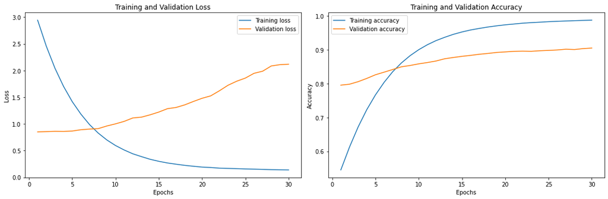

```python
plot_loss_acc_val_curves_from_history(history_model_vgg16_fe)
```

**Fine Tuning**

```python
history_model_vgg16_ft = pd.read_csv('./models_all/transfer_learning/vgg16/fine_tuning/model_history.csv')
```

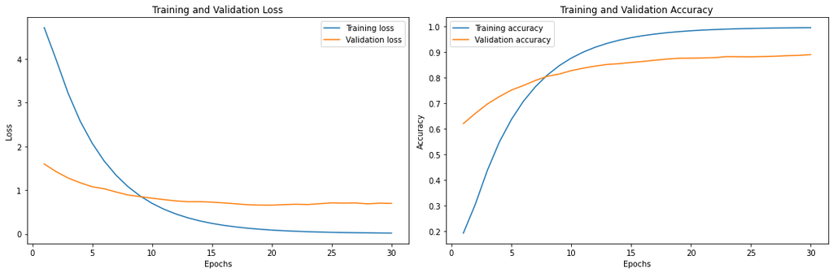

```python
plot_loss_acc_val_curves_from_history(history_model_vgg16_ft)
```

**Comparison**

```python
vgg16_model_histories = {}
vgg16_model_histories['vgg16_feature_extraction'] = history_model_vgg16_fe
vgg16_model_histories['vgg16_fine_tuning'] =history_model_vgg16_ft
```

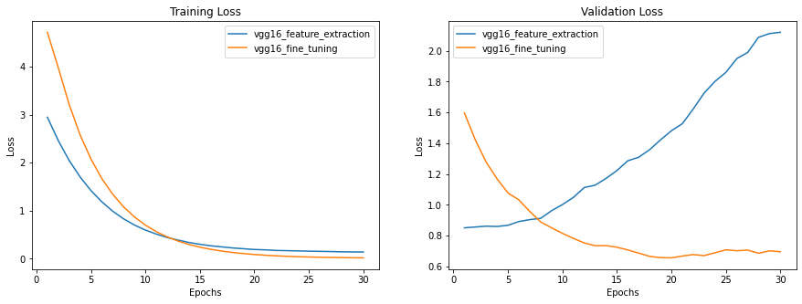

```python
plot_metric_models(vgg16_model_histories, 30, 'loss', 'Loss')
```

```python
model_vgg16_fe = models.load_model('./models_all/transfer_learning/vgg16/feature_extraction/model.h5')
```

```python
model_vgg16_ft = models.load_model('./models_all/transfer_learning/vgg16/fine_tuning/model.h5')
```

```python
vgg16_feature_extraction_score = model_vgg16_fe.evaluate(vgg_test_data_generator)
```

```python
vgg16_fine_tuning_score = model_vgg16_ft.evaluate(vgg_test_data_generator)
```

```python
print_metrics(vgg16_feature_extraction_score, 'VGG16 with feature extraction')
```

```
VGG16 with feature extraction Score
Accuracy: 0.9265000224113464
Precision: 0.9269635081291199
Recall: 0.9265000224113464
F1-score: 0.9267317073195351
```

```python
print_metrics(vgg16_fine_tuning_score, 'VGG16 with fine tuning')
```

```
VGG16 with fine tuning Score
Accuracy: 0.9125000238418579
Precision: 0.920040488243103
Recall: 0.9089999794960022
F1-score: 0.9144869123450854
```

The VGG16 model with feature extraction overfits faster than the model with fine tuning.

### Inception

InceptionV3 is a deep network with 42 layers that is more efficient than VGG. It makes use of factorization into smaller convolutions, asymmetric convolutions, grid size reduction [12].

```python
inception_img_generator = ImageDataGenerator(preprocessing_function = tf.keras.applications.inception_v3.preprocess_input)
```

```python
inception_test_data_generator = inception_img_generator.flow_from_directory(directory=TEST_DIR, shuffle=False, **dataflow_args)
```

```
Found 2000 images belonging to 400 classes.
```

**Feature extraction**

```python
history_model_inception_fe = pd.read_csv('./models_all/transfer_learning/inception/feature_extraction/model_history.csv')
```

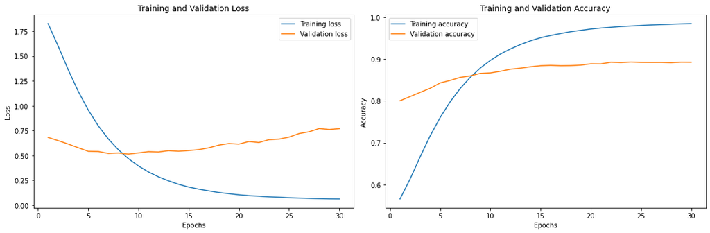

```python
plot_loss_acc_val_curves_from_history(history_model_inception_fe)
```

**Fine Tuning**

```python
history_model_inception_ft = pd.read_csv('./models_all/transfer_learning/inception/fine_tuning/model_history.csv')
```

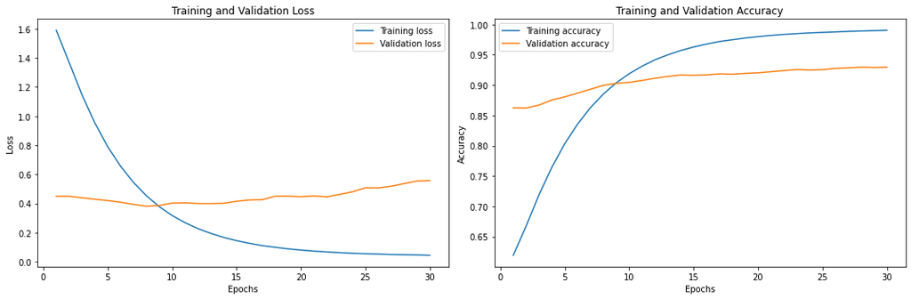

```python
plot_loss_acc_val_curves_from_history(history_model_inception_ft)
```

**Comparison**

```python
inception_model_histories = {}
inception_model_histories['inception_feature_extraction'] = history_model_inception_fe
inception_model_histories['inception_fine_tuning'] = history_model_inception_ft
```

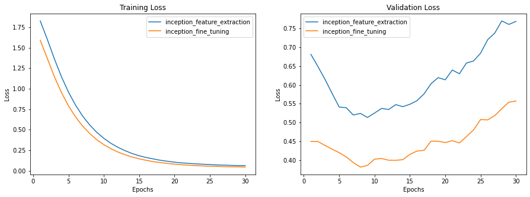

```python
plot_metric_models(inception_model_histories, 30, 'loss', 'Loss')
```

```python
model_inception_fe = models.load_model('./models_all/transfer_learning/inception/feature_extraction/model.h5')
```

```python
inception_feature_extraction_score = model_inception_fe.evaluate(inception_test_data_generator)
```

```python
model_inception_ft = models.load_model('./models_all/transfer_learning/inception/fine_tuning/model.h5')
```

```python
inception_fine_tuning_score = model_inception_ft.evaluate(inception_test_data_generator)
```

```python
print_metrics(inception_feature_extraction_score, 'Inception with feature extraction')
```

```
Inception with feature extraction Score
Accuracy: 0.9135000109672546
Precision: 0.9156202673912048
Recall: 0.9114999771118164
F1-score: 0.9135554764729863
```

```python
print_metrics(inception_fine_tuning_score, 'Inception with fine tuning')
```

```
Inception with fine tuning Score
Accuracy: 0.9509999752044678
Precision: 0.9538384079933167
Recall: 0.9505000114440918
F1-score: 0.9521662835341023
```

**Top predictions**

```python
Y_pred_inception_ft = model_inception_ft.predict(inception_test_data_generator)
y_pred_inception_ft = np.argmax(Y_pred_inception_ft, axis=1)
```

```python
all_classes_inception_ft, top_classes_inception_ft, low_classes_inception_ft = get_classification_report(inception_test_data_generator.classes,
                                                     inception_test_data_generator.class_indices.keys(),
                                                     y_pred_inception_ft)
```

```python
print('Number of bird classes with a F1-Score greater than 80%:', len(top_classes_inception_ft), '(', (len(top_classes_inception_ft)/CLASSES_COUNT)*100,'%)')
```

```
Number of bird classes with a F1-Score greater than 80%: 383 ( 95.75 %)
```

```python
print('Number of bird classes with a F1-Score less than 50%:', len(low_classes_inception_ft))
```

```
Number of bird classes with a F1-Score less than 50%: 1
```

```python
all_classes_inception_ft[-10:]
```

|  | precision | recall | f1-score | support |
| --- | --- | --- | --- | --- |
| ANTILLEAN EUPHONIA | 0.666667 | 0.8 | 0.727273 | 5.0 |
| CROWNED PIGEON | 0.666667 | 0.8 | 0.727273 | 5.0 |
| ABBOTTS BOOBY | 0.666667 | 0.8 | 0.727273 | 5.0 |
| RED TAILED HAWK | 0.666667 | 0.8 | 0.727273 | 5.0 |
| BRANDT CORMARANT | 0.750000 | 0.6 | 0.666667 | 5.0 |
| GREAT KISKADEE | 0.750000 | 0.6 | 0.666667 | 5.0 |
| STRAWBERRY FINCH | 0.750000 | 0.6 | 0.666667 | 5.0 |
| AZURE TIT | 1.000000 | 0.4 | 0.571429 | 5.0 |
| IMPERIAL SHAQ | 1.000000 | 0.4 | 0.571429 | 5.0 |
| AVADAVAT | 0.500000 | 0.4 | 0.444444 | 5.0 |

The InceptionV3 model with feature extraction overfits faster than the model with fine tuning.

### ResNet50

ResNet50 is a 50 layers deep convolutional neural network. It makes use of shortcut connections by skipping some layers and adding the output from an earlier layer to later layers. This is used to tackle the problem of vanishing/exploding gradients [13].

```python
resnet_img_generator = ImageDataGenerator(preprocessing_function = tf.keras.applications.resnet50.preprocess_input)
```

```python
resnet_test_data_generator = resnet_img_generator.flow_from_directory(directory=TEST_DIR, shuffle=False, **dataflow_args)
```

```
Found 2000 images belonging to 400 classes.
```

**Feature extraction**

```python
history_model_resnet_fe = pd.read_csv('./models_all/transfer_learning/resnet50/feature_extraction/model_history.csv')
```

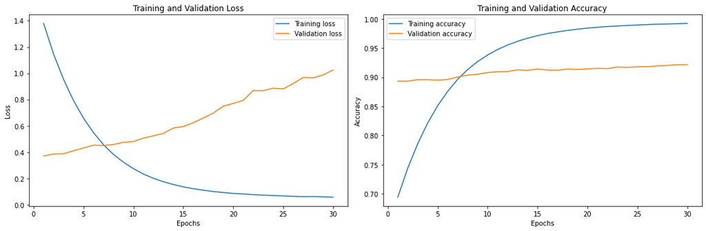

```python
plot_loss_acc_val_curves_from_history(history_model_resnet_fe)
```

**Fine tuning**

```python
history_model_resnet_ft = pd.read_csv('./models_all/transfer_learning/resnet50/fine_tuning/model_history.csv')
```

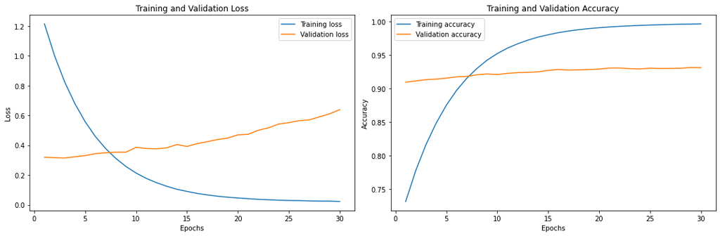

```python
plot_loss_acc_val_curves_from_history(history_model_resnet_ft)
```

**Comparison**

```python
resnet_model_histories = {}
resnet_model_histories['resnet_feature_extraction'] = history_model_resnet_fe
resnet_model_histories['resnet_fine_tuning'] =history_model_resnet_ft
```

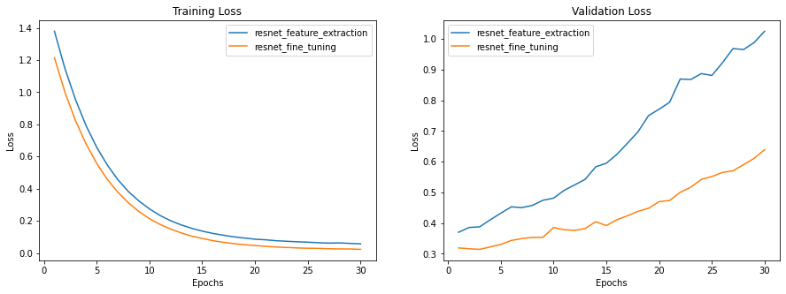

```python
plot_metric_models(resnet_model_histories, 30, 'loss', 'Loss')
```

```python
model_resnet_fe = models.load_model('./models_all/transfer_learning/resnet50/feature_extraction/model.h5')
```

```python
resnet_feature_extraction_score = model_resnet_fe.evaluate(resnet_test_data_generator)
```

```python
print_metrics(resnet_feature_extraction_score, 'ResNet50 with feature extraction')
```

```
ResNet50 with feature extraction Score
Accuracy: 0.9365000128746033
Precision: 0.9369685053825378
Recall: 0.9365000128746033
F1-score: 0.9367342005513306
```

```python
model_resnet_ft = models.load_model('./models_all/transfer_learning/resnet50/fine_tuning/model.h5')
```

```python
resnet_fine_tuning_score = model_resnet_ft.evaluate(resnet_test_data_generator)
```

```python
print_metrics(resnet_fine_tuning_score, 'ResNet50 with fine tuning')
```

```
ResNet50 with fine tuning Score
Accuracy: 0.9434999823570251
Precision: 0.9472891688346863
Recall: 0.9434999823570251
F1-score: 0.9453907787858958
```

The ResNet50 model with feature extraction overfits faster than the model with fine tuning.

### EfficientNet

EfficientNet is a convolutional neural network that uses a scaling method that uniformly scales the depth, width and resolution dimensions by using a compound coefficient [14].

```python
efficient_img_generator = ImageDataGenerator(preprocessing_function = tf.keras.applications.efficientnet.preprocess_input)
```

```python
efficient_test_data_generator = efficient_img_generator.flow_from_directory(directory=TEST_DIR, shuffle=False, **dataflow_args)
```

```
Found 2000 images belonging to 400 classes.
```

**Feature extraction**

```python
history_model_efficient_fe = pd.read_csv('./models_all/transfer_learning/efficientnet/feature_extraction/model_history.csv')
```

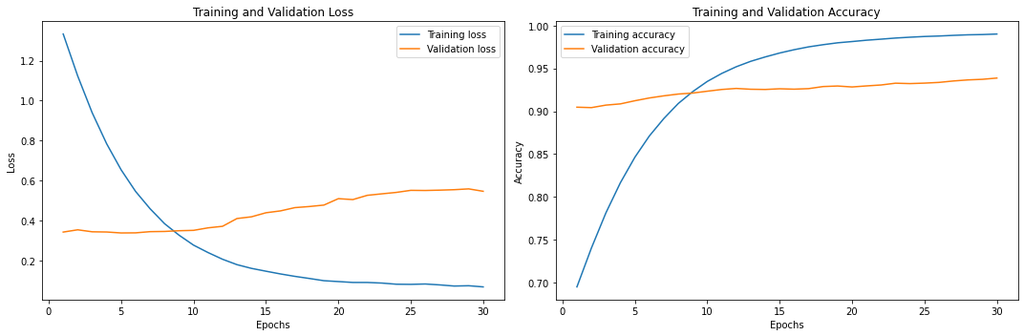

```python
plot_loss_acc_val_curves_from_history(history_model_efficient_fe)
```

**Fine tuning**

```python
#*********************************
# Adapted from
# Author: FU, Y
# Source: Keras. Image classification via fine-tuning with EfficientNet. https://keras.io/examples/vision/image_classification_efficientnet_fine_tuning/#transfer-learning-from-pretrained-weights [15]
#*********************************
def get_efficientnet_fine_tuning():

    efficientnet_model = EfficientNetB0(weights='imagenet',
                                        include_top=False,
                                        input_shape=(IMG_SIZE, IMG_SIZE,3))

    # Unfreeze the top 20 layers that are not batch normalization
    for eff_layer in efficientnet_model.layers[-20:]:
        if not isinstance(eff_layer, layers.BatchNormalization):
            eff_layer.trainable = True
        else:
            eff_layer.trainable = False

    # add a dense classifier
    layer0 = tf.keras.layers.Flatten()(efficientnet_model.output)
    layer1 = tf.keras.layers.Dense(4096, activation='relu')(layer0)
    layer2 = tf.keras.layers.Dropout(0.5)(layer1)
    layer3 = tf.keras.layers.Dense(4096, activation='relu')(layer2)
    out_layer = tf.keras.layers.Dense(CLASSES_COUNT, activation='softmax')(layer3)
    efficientnet_model = tf.keras.Model(efficientnet_model.input, out_layer)

    efficientnet_model.compile(optimizer=tf.keras.optimizers.Adam(learning_rate=0.0001),
                    loss='categorical_crossentropy',
                    metrics=['acc', Precision(name='precision'), Recall(name='recall')])

    return efficientnet_model
```

```python
history_model_efficient_ft = pd.read_csv('./models_all/transfer_learning/efficientnet/fine_tuning/model_history.csv')
```

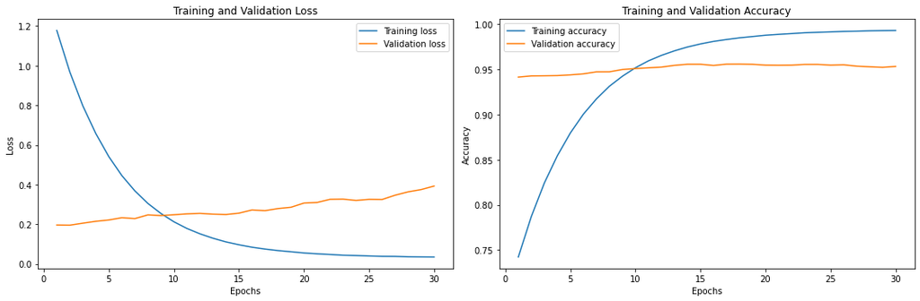

```python
plot_loss_acc_val_curves_from_history(history_model_efficient_ft)
```

#### Comparison

```python
efficient_model_histories = {}
efficient_model_histories['efficient_feature_extraction'] = history_model_efficient_fe
efficient_model_histories['efficient_fine_tuning'] =history_model_efficient_ft
```

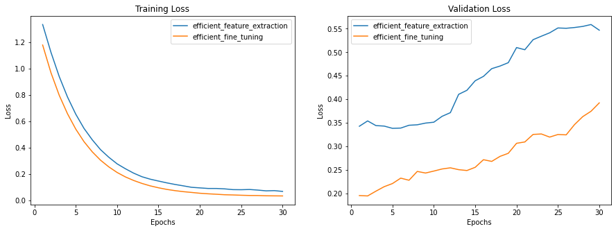

```python
plot_metric_models(efficient_model_histories, 30, 'loss', 'Loss')
```

```python
model_efficient_fe = models.load_model('./models_all/transfer_learning/efficientnet/feature_extraction/model.h5')
```

```python
efficient_feature_extraction_score = model_efficient_fe.evaluate(efficient_test_data_generator)
```

```python
model_efficient_ft = models.load_model('./models_all/transfer_learning/efficientnet/fine_tuning/model.h5')
```

```python
efficient_fine_tuning_score = model_efficient_ft.evaluate(efficient_test_data_generator)
```

```python
print_metrics(efficient_feature_extraction_score, 'EfficientNetB0 with feature extraction')
```

```
EfficientNetB0 with feature extraction Score
Accuracy: 0.9539999961853027
Precision: 0.9544544816017151
Recall: 0.953499972820282
F1-score: 0.9539769884508406
```

```python
print_metrics(efficient_fine_tuning_score, 'EfficientNetB0 with fine tuning')
```

```
EfficientNetB0 with fine tuning Score
Accuracy: 0.9660000205039978
Precision: 0.9669172763824463
Recall: 0.9645000100135803
F1-score: 0.9657071305324855
```

### Compare all pretrained models

```python
pretrained_model_histories = {}
pretrained_model_histories['VGG16'] = history_model_vgg16_ft
pretrained_model_histories['InceptionV3'] = history_model_inception_ft
pretrained_model_histories['ResNet50'] = history_model_resnet_ft
pretrained_model_histories['EfficientNet'] = history_model_efficient_ft
```

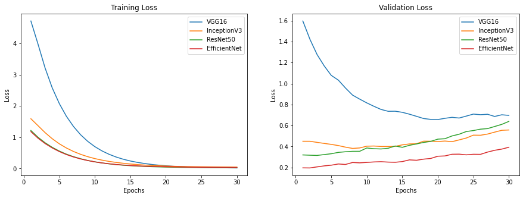

```python
plot_metric_models(pretrained_model_histories, 30, 'loss', 'Loss')
```

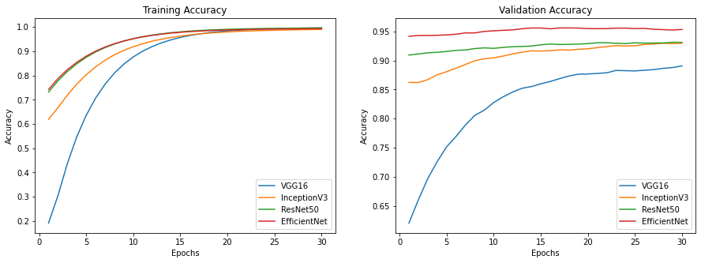

```python
plot_metric_models(pretrained_model_histories, 30, 'acc', 'Accuracy')
```

From the four pre-trained models, EfficientNet achieved the higher accuracy and has the lowest loss.

**Top classes EfficientNetB0**

```python
Y_pred_efficient_ft = model_efficient_ft.predict(efficient_test_data_generator)
y_pred_efficient_ft = np.argmax(Y_pred_efficient_ft, axis=1)
```

```python
all_classes_efficient_ft, top_classes_efficient_ft, low_classes_efficient_ft = get_classification_report(efficient_test_data_generator.classes,
                                                     efficient_test_data_generator.class_indices.keys(),
                                                     y_pred_efficient_ft)
```

```python
print('Number of bird classes with a F1-Score greater than 80%:', len(top_classes_efficient_ft), '(', len(top_classes_efficient_ft)/CLASSES_COUNT*100,'%)')
```

```
Number of bird classes with a F1-Score greater than 80%: 390 ( 97.5 %)
```

```python
print('Number of bird classes with a F1-Score less than 50%:', len(low_classes_efficient_ft))
```

```
Number of bird classes with a F1-Score less than 50%: 1
```

**Top 10 with lowest F1 score**

```python
all_classes_efficient_ft[-10:]
```

|  | precision | recall | f1-score | support |
| --- | --- | --- | --- | --- |
| TROPICAL KINGBIRD | 0.625000 | 1.0 | 0.769231 | 5.0 |
| RED TAILED HAWK | 1.000000 | 0.6 | 0.750000 | 5.0 |
| WHITE THROATED BEE EATER | 1.000000 | 0.6 | 0.750000 | 5.0 |
| ALTAMIRA YELLOWTHROAT | 1.000000 | 0.6 | 0.750000 | 5.0 |
| ANDEAN GOOSE | 1.000000 | 0.6 | 0.750000 | 5.0 |
| CRIMSON CHAT | 1.000000 | 0.6 | 0.750000 | 5.0 |
| CANARY | 0.571429 | 0.8 | 0.666667 | 5.0 |
| BLACK SKIMMER | 0.600000 | 0.6 | 0.600000 | 5.0 |
| STRAWBERRY FINCH | 0.666667 | 0.4 | 0.500000 | 5.0 |
| AVADAVAT | 0.400000 | 0.4 | 0.400000 | 5.0 |

Since EfficientNet with fine tuning is the pretrained model that achieved the highest accuracy (96.6%) and F1 score (96.57%), I will add data augmentation to improve it.

### Pre-trained model with data augmentation

```python
history_model_efficient_aug = pd.read_csv('./models_all/transfer_learning/efficientnet/fine_tuning_aug/model_history.csv')
```

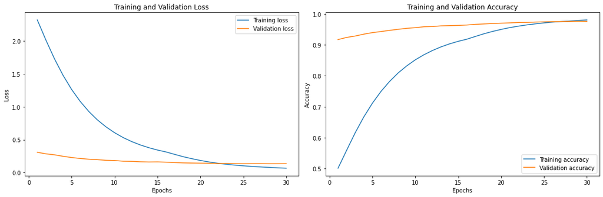

```python
plot_loss_acc_val_curves_from_history(history_model_efficient_aug)
```

```python
model_efficient_aug = models.load_model('./models_all/transfer_learning/efficientnet/fine_tuning_aug/model.h5')
```

```python
efficient_aug_score = model_efficient_aug.evaluate(efficient_test_data_generator)
```

```python
print_metrics(efficient_aug_score, 'EfficientNetB0 with fine tuning and data augmentation')
```

```
EfficientNetB0 with fine tuning and data augmentation Score
Accuracy: 0.984499990940094
Precision: 0.984499990940094
Recall: 0.984499990940094
F1-score: 0.984499990940094
```

**Top predicted classes**

```python
Y_pred_efficient_aug = model_efficient_aug.predict(efficient_test_data_generator)
y_pred_efficient_aug = np.argmax(Y_pred_efficient_aug, axis=1)
```

```python
all_classes_efficient_aug, top_classes_efficient_aug, low_classes_efficient_aug = get_classification_report(efficient_test_data_generator.classes,
                                                     efficient_test_data_generator.class_indices.keys(),
                                                     y_pred_efficient_aug)
```

```python
print('Number of bird classes with a F1-Score greater than 80%:', len(top_classes_efficient_aug) , '(', (len(top_classes_efficient_aug)/CLASSES_COUNT)*100,'%)')
```

```
Number of bird classes with a F1-Score greater than 80%: 392 ( 98.0 %)
```

```python
print('Number of bird classes with a F1-Score less than 50%:', len(low_classes_efficient_aug))
```

```
Number of bird classes with a F1-Score less than 50%: 0
```

**Top 10 with lowest F1 score**

```python
all_classes_efficient_aug[-10:]
```

|  | precision | recall | f1-score | support |
| --- | --- | --- | --- | --- |
| BRANDT CORMARANT | 0.714286 | 1.0 | 0.833333 | 5.0 |
| PYGMY KINGFISHER | 0.714286 | 1.0 | 0.833333 | 5.0 |
| MALACHITE KINGFISHER | 1.000000 | 0.6 | 0.750000 | 5.0 |
| GILA WOODPECKER | 1.000000 | 0.6 | 0.750000 | 5.0 |
| GREAT POTOO | 1.000000 | 0.6 | 0.750000 | 5.0 |
| GILDED FLICKER | 1.000000 | 0.6 | 0.750000 | 5.0 |
| CINNAMON TEAL | 1.000000 | 0.6 | 0.750000 | 5.0 |
| AVADAVAT | 0.571429 | 0.8 | 0.666667 | 5.0 |
| STRAWBERRY FINCH | 1.000000 | 0.4 | 0.571429 | 5.0 |
| DOUBLE BRESTED CORMARANT | 1.000000 | 0.4 | 0.571429 | 5.0 |

Adding data augmentation, improved the EfficientNet with fine tuning from 96.6% to 98.44% accuracy.

### Option 3: Model ensembling

Model ensembling is the process of combining the predictions of different models in order to get better predictions. It can be done by computing the average or weighted average of different models [1].

In this case, I will use the models that achieved a higher accuarcy: best model from scratch with data augmentation (94.35%), EfficientNetB0 with fine tuning and data augmentation (98.44%) and InceptionV3 with fine tuning (95.09%).

#### Method 1: Average predictions

```python
def ensemble_average_predict(weighted=False, w_scratch=0.33, w_efficient=0.33, w_inception=0.33):

    """Makes prediction based on the average of the predictions from the scratch, EfficientNet and Inception models

    Parameters
    ----------
    weighted : boolean
        True if using weighted average
    w_scratch : int
        weight for the scratch model
    w_efficient : int
        weight for the Efficientnet model
    w_inception : int
        weight for the Inception model

    Returns
    -------
    Returns accuracy, precision, recall and F1-score
    """

    true_labels = test_generator.labels
    predicted_labels = []

    # iterate through each batch
    for batch_i in range(len(test_generator)):

        batch_efficient = efficient_test_data_generator.__getitem__(batch_i)
        batch_scratch = test_generator.__getitem__(batch_i)
        batch_inception = inception_test_data_generator.__getitem__(batch_i)

        # iterate through each image of the selected batch
        for i in range(len(batch_scratch[0])):
            img_efficient = batch_efficient[0][i].reshape(1,224,224,3)
            img_scratch = batch_scratch[0][i].reshape(1,224,224,3)
            img_inception = batch_inception[0][i].reshape(1,224,224,3)

            # get a prediction from each model
            pred_a = model_efficient_aug.predict(img_efficient)
            pred_b = model_tuned_data_aug.predict(img_scratch)
            pred_c = model_inception_ft.predict(img_inception)
            # get prediction average or weighted average
            if(weighted):
                summed = (w_efficient * pred_a) + (w_scratch * pred_b) + (w_inception * pred_c)
            else:
                summed = np.sum([pred_a, pred_b, pred_c], axis=0)
            # add prediction to array of predictions
            result = np.argmax(summed, axis=1)
            predicted_labels.append(result)

    return predicted_labels, true_labels
```

```python
def get_scores(predicted_labels, true_labels):

    acc = accuracy_score(predicted_labels, true_labels)
    prec = precision_score(predicted_labels, true_labels, average='macro')
    rec = recall_score(predicted_labels, true_labels, average='macro')
    f1 = f1_score(predicted_labels, true_labels, average='macro')

    return acc, prec, rec, f1
```

```python
ensemble_predicted_labels, true_labels = ensemble_average_predict()
```

```python
ensemble_acc, ensemble_prec, ensemble_rec, ensemble_f1 = get_scores(ensemble_predicted_labels, true_labels)
```

```python
print('Average prediction ensemble model')
print('Accuracy', ensemble_acc)
print('Precision', ensemble_prec)
print('Recall', ensemble_rec)
print('F1-score', ensemble_f1)
```

```
Average prediction ensemble model
Accuracy 0.99
Precision 0.99
Recall 0.9920833333333334
F1-score 0.9897934704184705
```

**Top predicted classes**

```python
all_classes_ensemble, top_classes_ensemble, low_classes_ensemble = get_classification_report(test_generator.classes,
                                                     test_generator.class_indices.keys(),
                                                     ensemble_predicted_labels)
```

```python
print('Number of bird classes with a F1-Score greater than 80%:', len(top_classes_ensemble), '(', (len(top_classes_ensemble)/CLASSES_COUNT)*100,'%)')
```

```
Number of bird classes with a F1-Score greater than 80%: 397 ( 99.25 %)
```

```python
print('Number of bird classes with a F1-Score less than 50%:', len(low_classes_ensemble))
```

```
Number of bird classes with a F1-Score less than 50%: 0
```

**Top 10 Classes with lowest F1 score**

```python
all_classes_ensemble[-10:]
```

|  | precision | recall | f1-score | support |
| --- | --- | --- | --- | --- |
| ALTAMIRA YELLOWTHROAT | 1.000000 | 0.8 | 0.888889 | 5.0 |
| ANTILLEAN EUPHONIA | 1.000000 | 0.8 | 0.888889 | 5.0 |
| VULTURINE GUINEAFOWL | 1.000000 | 0.8 | 0.888889 | 5.0 |
| RED FACED CORMORANT | 1.000000 | 0.8 | 0.888889 | 5.0 |
| WHITE CHEEKED TURACO | 1.000000 | 0.8 | 0.888889 | 5.0 |
| CAPE MAY WARBLER | 0.714286 | 1.0 | 0.833333 | 5.0 |
| PYGMY KINGFISHER | 0.714286 | 1.0 | 0.833333 | 5.0 |
| MALACHITE KINGFISHER | 1.000000 | 0.6 | 0.750000 | 5.0 |
| AVADAVAT | 0.571429 | 0.8 | 0.666667 | 5.0 |
| STRAWBERRY FINCH | 1.000000 | 0.4 | 0.571429 | 5.0 |

By averaging the predictions of each of the selected models, the model ensembling process achieved a higher accuracy of 99%.

**Method 2: Weighted average**

In order to get the weight for each model a simple model with one convolutional layer and three params is trained on the predictions made by each of the three best models.

```python
model_weighted_ensemble = models.load_model('./models_all/ensemble/weighted_average/model.h5')
```

```python
model_weighted_ensemble.summary()
```

```
Model: "model"
_________________________________________________________________
 Layer (type)                Output Shape              Param #
=================================================================
 input_1 (InputLayer)        [(None, 400, 3)]          0

 conv1d (Conv1D)             (None, 400, 1)            3

 flatten (Flatten)           (None, 400)               0

 softmax (Softmax)           (None, 400)               0

=================================================================
Total params: 3
Trainable params: 3
Non-trainable params: 0
_________________________________________________________________
```

```python
ensemble_weights = model_weighted_ensemble.layers[1].get_weights()
ensemble_weights = ensemble_weights/np.sum(ensemble_weights)
scratch_weight, efficient_weight, inception_weight = ensemble_weights[0][0][0][0], ensemble_weights[0][0][1][0], ensemble_weights[0][0][2][0]
```

Weight for each model:

```python
print('Scratch model:', scratch_weight)
print('EfficientNet model:', efficient_weight)
print('Inception model:', inception_weight)
```

```
Scratch model: 0.24762568
EfficientNet model: 0.39269462
Inception model: 0.35967973
```

```python
ensemble_weighted_predicted_labels, true_labels = ensemble_average_predict(True, scratch_weight, efficient_weight, inception_weight)
```

```python
ensemble_w_acc, ensemble_w_prec, ensemble_w_rec, ensemble_w_f1 = get_scores(ensemble_weighted_predicted_labels, true_labels)
```

```python
print('Average prediction ensemble model')
print('Accuracy', ensemble_w_acc)
print('Precision', ensemble_w_prec)
print('Recall', ensemble_w_rec)
print('F1-score', ensemble_w_f1)
```

```
Average prediction ensemble model
Accuracy 0.9905
Precision 0.9904999999999999
Recall 0.9923809523809524
F1-score 0.9903300865800866
```

**Top predicted class**

```python
all_classes_ensemble_weighted, top_classes_ensemble_weighted, low_classes_ensemble_weighted = get_classification_report(test_generator.classes,
                                                     test_generator.class_indices.keys(),
                                                     ensemble_weighted_predicted_labels)
```

```python
print('Number of bird classes with a F1-Score greater than 80%:', len(top_classes_ensemble_weighted), '(', (len(top_classes_ensemble_weighted)/CLASSES_COUNT)*100,'%)')
```

```
Number of bird classes with a F1-Score greater than 80%: 398 ( 99.5 %)
```

```python
print('Number of bird classes with a F1-Score less than 50%:', len(low_classes_ensemble_weighted))
```

```
Number of bird classes with a F1-Score less than 50%: 0
```

**Top 10 Classes with lowest F1 score**

```python
all_classes_ensemble_weighted[-10:]
```

|  | precision | recall | f1-score | support |
| --- | --- | --- | --- | --- |
| GILDED FLICKER | 1.000000 | 0.8 | 0.888889 | 5.0 |
| GILA WOODPECKER | 1.000000 | 0.8 | 0.888889 | 5.0 |
| TOWNSENDS WARBLER | 1.000000 | 0.8 | 0.888889 | 5.0 |
| AMERICAN REDSTART | 1.000000 | 0.8 | 0.888889 | 5.0 |
| VULTURINE GUINEAFOWL | 1.000000 | 0.8 | 0.888889 | 5.0 |
| MALACHITE KINGFISHER | 1.000000 | 0.8 | 0.888889 | 5.0 |
| WHITE CHEEKED TURACO | 1.000000 | 0.8 | 0.888889 | 5.0 |
| CAPE MAY WARBLER | 0.714286 | 1.0 | 0.833333 | 5.0 |
| AVADAVAT | 0.571429 | 0.8 | 0.666667 | 5.0 |
| STRAWBERRY FINCH | 1.000000 | 0.4 | 0.571429 | 5.0 |

Using the weighted average only did a slightly improved to 99.05% accuracy.